# Factors affecting Loan status and their effects Loan interest

## (Visualization 3)

This plot shows that borrowers rate decreases with increasing income ranges, the interest given for each loan decreases with the clients income range, for clients with high income range, the interest rate is small compared with clients of low income range.This is done to encourage low income earners to collect loans for the expansion of their businesses. This is so for all years, although in 2014, there is no data for umployed and people with low income status.

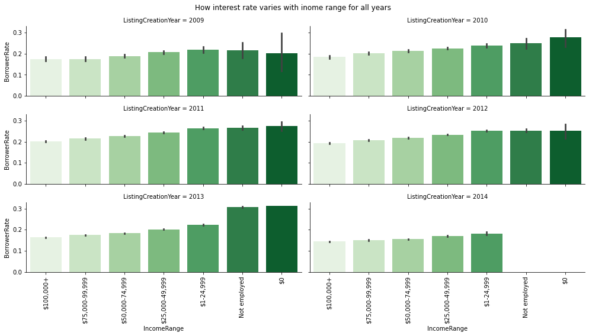

## Visualization 4

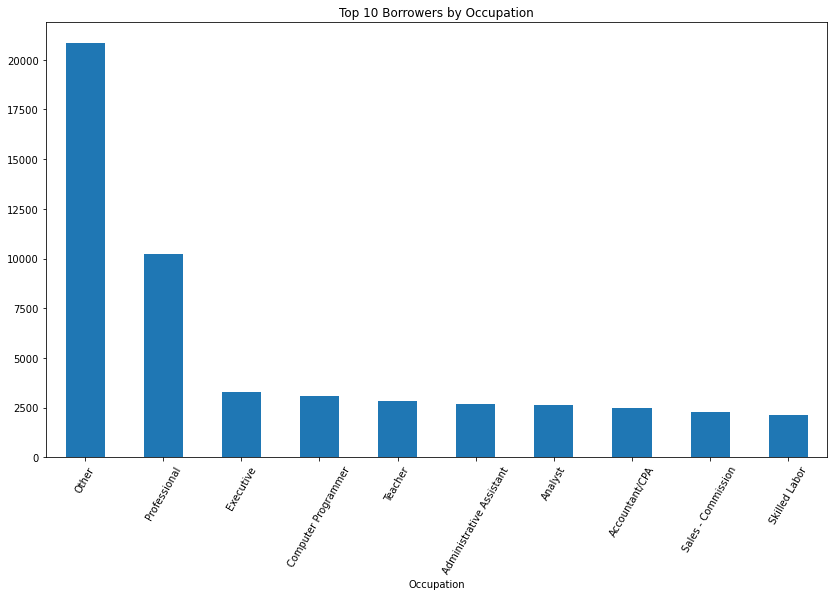